# Risk Factor Analysis

## Outcome Variable

**Outcome Variable:** sstunted

## Predictor Variables

**Intervention Variable:** mage

**Adjustment Set:**

unadjusted

## Stratifying Variables

The analysis was stratified on these variable(s):

- agecat
- studyid
- country

## Data Summary

| agecat | studyid | country | mage | sstunted | n_cell | n |
| --- | --- | --- | --- | --- | --- | --- |
| Birth | ki0047075b-MAL-ED | BANGLADESH | <25 | 0 | 115 | 257 |
| Birth | ki0047075b-MAL-ED | BANGLADESH | <25 | 1 | 5 | 257 |
| Birth | ki0047075b-MAL-ED | BANGLADESH | [25-30) | 0 | 90 | 257 |
| Birth | ki0047075b-MAL-ED | BANGLADESH | [25-30) | 1 | 2 | 257 |
| Birth | ki0047075b-MAL-ED | BANGLADESH | >=30 | 0 | 43 | 257 |
| Birth | ki0047075b-MAL-ED | BANGLADESH | >=30 | 1 | 2 | 257 |
| Birth | ki0047075b-MAL-ED | BRAZIL | <25 | 0 | 95 | 191 |
| Birth | ki0047075b-MAL-ED | BRAZIL | <25 | 1 | 2 | 191 |
| Birth | ki0047075b-MAL-ED | BRAZIL | [25-30) | 0 | 49 | 191 |
| Birth | ki0047075b-MAL-ED | BRAZIL | [25-30) | 1 | 5 | 191 |
| Birth | ki0047075b-MAL-ED | BRAZIL | >=30 | 0 | 39 | 191 |
| Birth | ki0047075b-MAL-ED | BRAZIL | >=30 | 1 | 1 | 191 |
| Birth | ki0047075b-MAL-ED | INDIA | <25 | 0 | 118 | 205 |
| Birth | ki0047075b-MAL-ED | INDIA | <25 | 1 | 4 | 205 |
| Birth | ki0047075b-MAL-ED | INDIA | [25-30) | 0 | 65 | 205 |
| Birth | ki0047075b-MAL-ED | INDIA | [25-30) | 1 | 3 | 205 |
| Birth | ki0047075b-MAL-ED | INDIA | >=30 | 0 | 15 | 205 |
| Birth | ki0047075b-MAL-ED | INDIA | >=30 | 1 | 0 | 205 |
| Birth | ki0047075b-MAL-ED | NEPAL | <25 | 0 | 44 | 173 |
| Birth | ki0047075b-MAL-ED | NEPAL | <25 | 1 | 2 | 173 |
| Birth | ki0047075b-MAL-ED | NEPAL | [25-30) | 0 | 88 | 173 |
| Birth | ki0047075b-MAL-ED | NEPAL | [25-30) | 1 | 3 | 173 |
| Birth | ki0047075b-MAL-ED | NEPAL | >=30 | 0 | 35 | 173 |
| Birth | ki0047075b-MAL-ED | NEPAL | >=30 | 1 | 1 | 173 |
| Birth | ki0047075b-MAL-ED | PERU | <25 | 0 | 156 | 287 |
| Birth | ki0047075b-MAL-ED | PERU | <25 | 1 | 5 | 287 |
| Birth | ki0047075b-MAL-ED | PERU | [25-30) | 0 | 59 | 287 |
| Birth | ki0047075b-MAL-ED | PERU | [25-30) | 1 | 2 | 287 |
| Birth | ki0047075b-MAL-ED | PERU | >=30 | 0 | 64 | 287 |
| Birth | ki0047075b-MAL-ED | PERU | >=30 | 1 | 1 | 287 |

[output cut: 378 more lines]

The following strata were considered:

- agecat: 24 months, studyid: ki0047075b-MAL-ED, country: BANGLADESH
- agecat: 24 months, studyid: ki0047075b-MAL-ED, country: BRAZIL
- agecat: 24 months, studyid: ki0047075b-MAL-ED, country: INDIA
- agecat: 24 months, studyid: ki0047075b-MAL-ED, country: NEPAL
- agecat: 24 months, studyid: ki0047075b-MAL-ED, country: PERU
- agecat: 24 months, studyid: ki0047075b-MAL-ED, country: SOUTH AFRICA
- agecat: 24 months, studyid: ki0047075b-MAL-ED, country: TANZANIA, UNITED REPUBLIC OF
- agecat: 24 months, studyid: ki1000108-CMC-V-BCS-2002, country: INDIA
- agecat: 24 months, studyid: ki1000108-IRC, country: INDIA
- agecat: 24 months, studyid: ki1017093-NIH-Birth, country: BANGLADESH
- agecat: 24 months, studyid: ki1017093b-PROVIDE, country: BANGLADESH
- agecat: 24 months, studyid: ki1017093c-NIH-Crypto, country: BANGLADESH
- agecat: 24 months, studyid: ki1066203-TanzaniaChild2, country: TANZANIA, UNITED REPUBLIC OF
- agecat: 24 months, studyid: ki1101329-Keneba, country: GAMBIA
- agecat: 24 months, studyid: ki1113344-GMS-Nepal, country: NEPAL
- agecat: 24 months, studyid: ki1119695-PROBIT, country: BELARUS
- agecat: 24 months, studyid: ki1126311-ZVITAMBO, country: ZIMBABWE
- agecat: 24 months, studyid: ki1135781-COHORTS, country: GUATEMALA
- agecat: 24 months, studyid: ki1135781-COHORTS, country: INDIA
- agecat: 24 months, studyid: ki1135781-COHORTS, country: PHILIPPINES
- agecat: 24 months, studyid: ki1148112-LCNI-5, country: MALAWI
- agecat: 24 months, studyid: kiGH5241-JiVitA-3, country: BANGLADESH
- agecat: 6 months, studyid: ki0047075b-MAL-ED, country: BANGLADESH
- agecat: 6 months, studyid: ki0047075b-MAL-ED, country: BRAZIL
- agecat: 6 months, studyid: ki0047075b-MAL-ED, country: INDIA
- agecat: 6 months, studyid: ki0047075b-MAL-ED, country: NEPAL
- agecat: 6 months, studyid: ki0047075b-MAL-ED, country: PERU
- agecat: 6 months, studyid: ki0047075b-MAL-ED, country: SOUTH AFRICA
- agecat: 6 months, studyid: ki0047075b-MAL-ED, country: TANZANIA, UNITED REPUBLIC OF
- agecat: 6 months, studyid: ki1000108-CMC-V-BCS-2002, country: INDIA
- agecat: 6 months, studyid: ki1000108-IRC, country: INDIA
- agecat: 6 months, studyid: ki1000109-EE, country: PAKISTAN
- agecat: 6 months, studyid: ki1000304b-SAS-CompFeed, country: INDIA
- agecat: 6 months, studyid: ki1000304b-SAS-FoodSuppl, country: INDIA
- agecat: 6 months, studyid: ki1017093-NIH-Birth, country: BANGLADESH
- agecat: 6 months, studyid: ki1017093b-PROVIDE, country: BANGLADESH
- agecat: 6 months, studyid: ki1017093c-NIH-Crypto, country: BANGLADESH
- agecat: 6 months, studyid: ki1066203-TanzaniaChild2, country: TANZANIA, UNITED REPUBLIC OF
- agecat: 6 months, studyid: ki1101329-Keneba, country: GAMBIA
- agecat: 6 months, studyid: ki1112895-Guatemala BSC, country: GUATEMALA
- agecat: 6 months, studyid: ki1113344-GMS-Nepal, country: NEPAL
- agecat: 6 months, studyid: ki1119695-PROBIT, country: BELARUS
- agecat: 6 months, studyid: ki1126311-ZVITAMBO, country: ZIMBABWE
- agecat: 6 months, studyid: ki1135781-COHORTS, country: GUATEMALA
- agecat: 6 months, studyid: ki1135781-COHORTS, country: INDIA
- agecat: 6 months, studyid: ki1135781-COHORTS, country: PHILIPPINES
- agecat: 6 months, studyid: ki1148112-LCNI-5, country: MALAWI
- agecat: 6 months, studyid: kiGH5241-JiVitA-3, country: BANGLADESH
- agecat: Birth, studyid: ki0047075b-MAL-ED, country: BANGLADESH
- agecat: Birth, studyid: ki0047075b-MAL-ED, country: BRAZIL
- agecat: Birth, studyid: ki0047075b-MAL-ED, country: INDIA
- agecat: Birth, studyid: ki0047075b-MAL-ED, country: NEPAL
- agecat: Birth, studyid: ki0047075b-MAL-ED, country: PERU
- agecat: Birth, studyid: ki0047075b-MAL-ED, country: SOUTH AFRICA
- agecat: Birth, studyid: ki0047075b-MAL-ED, country: TANZANIA, UNITED REPUBLIC OF
- agecat: Birth, studyid: ki1000108-CMC-V-BCS-2002, country: INDIA
- agecat: Birth, studyid: ki1000108-IRC, country: INDIA
- agecat: Birth, studyid: ki1000109-EE, country: PAKISTAN
- agecat: Birth, studyid: ki1000304b-SAS-CompFeed, country: INDIA
- agecat: Birth, studyid: ki1017093-NIH-Birth, country: BANGLADESH
- agecat: Birth, studyid: ki1017093c-NIH-Crypto, country: BANGLADESH
- agecat: Birth, studyid: ki1101329-Keneba, country: GAMBIA
- agecat: Birth, studyid: ki1119695-PROBIT, country: BELARUS
- agecat: Birth, studyid: ki1126311-ZVITAMBO, country: ZIMBABWE
- agecat: Birth, studyid: ki1135781-COHORTS, country: GUATEMALA
- agecat: Birth, studyid: ki1135781-COHORTS, country: INDIA
- agecat: Birth, studyid: ki1135781-COHORTS, country: PHILIPPINES
- agecat: Birth, studyid: kiGH5241-JiVitA-3, country: BANGLADESH

### Dropped Strata

Some strata were dropped due to rare outcomes:

- agecat: Birth, studyid: ki0047075b-MAL-ED, country: BANGLADESH
- agecat: Birth, studyid: ki0047075b-MAL-ED, country: BRAZIL
- agecat: Birth, studyid: ki0047075b-MAL-ED, country: INDIA
- agecat: Birth, studyid: ki0047075b-MAL-ED, country: NEPAL
- agecat: Birth, studyid: ki0047075b-MAL-ED, country: PERU
- agecat: Birth, studyid: ki0047075b-MAL-ED, country: SOUTH AFRICA
- agecat: Birth, studyid: ki0047075b-MAL-ED, country: TANZANIA, UNITED REPUBLIC OF
- agecat: Birth, studyid: ki1000108-CMC-V-BCS-2002, country: INDIA
- agecat: Birth, studyid: ki1000108-IRC, country: INDIA
- agecat: Birth, studyid: ki1000109-EE, country: PAKISTAN
- agecat: Birth, studyid: ki1000304b-SAS-CompFeed, country: INDIA
- agecat: Birth, studyid: ki1017093-NIH-Birth, country: BANGLADESH
- agecat: Birth, studyid: ki1017093c-NIH-Crypto, country: BANGLADESH
- agecat: Birth, studyid: ki1101329-Keneba, country: GAMBIA
- agecat: Birth, studyid: ki1119695-PROBIT, country: BELARUS
- agecat: Birth, studyid: ki1135781-COHORTS, country: GUATEMALA
- agecat: 6 months, studyid: ki0047075b-MAL-ED, country: BANGLADESH
- agecat: 6 months, studyid: ki0047075b-MAL-ED, country: BRAZIL
- agecat: 6 months, studyid: ki0047075b-MAL-ED, country: INDIA
- agecat: 6 months, studyid: ki0047075b-MAL-ED, country: NEPAL
- agecat: 6 months, studyid: ki0047075b-MAL-ED, country: PERU
- agecat: 6 months, studyid: ki0047075b-MAL-ED, country: SOUTH AFRICA
- agecat: 6 months, studyid: ki0047075b-MAL-ED, country: TANZANIA, UNITED REPUBLIC OF
- agecat: 6 months, studyid: ki1000108-IRC, country: INDIA
- agecat: 6 months, studyid: ki1017093b-PROVIDE, country: BANGLADESH
- agecat: 6 months, studyid: ki1066203-TanzaniaChild2, country: TANZANIA, UNITED REPUBLIC OF
- agecat: 6 months, studyid: ki1112895-Guatemala BSC, country: GUATEMALA
- agecat: 6 months, studyid: ki1113344-GMS-Nepal, country: NEPAL
- agecat: 24 months, studyid: ki0047075b-MAL-ED, country: BRAZIL
- agecat: 24 months, studyid: ki0047075b-MAL-ED, country: INDIA
- agecat: 24 months, studyid: ki0047075b-MAL-ED, country: NEPAL
- agecat: 24 months, studyid: ki0047075b-MAL-ED, country: PERU
- agecat: 24 months, studyid: ki0047075b-MAL-ED, country: SOUTH AFRICA
- agecat: 24 months, studyid: ki1000108-IRC, country: INDIA
- agecat: 24 months, studyid: ki1017093c-NIH-Crypto, country: BANGLADESH
- agecat: 24 months, studyid: ki1066203-TanzaniaChild2, country: TANZANIA, UNITED REPUBLIC OF

## Methods Detail

We’re interested in the causal parameters $E[Y_a]$ for all values of $a \in \mathcal{A}$. These parameters represent the mean outcome if, possibly contrary to fact, we intervened to set all units to have $A=a$. Under the randomization and positivity assumptions, these are identified by the statistical parameters $\psi_a=E_W[E_{Y|A,W}(Y|A=a,W)]$. In addition, we’re interested in the mean of $Y$, $E[Y]$ under no intervention (the observed mean). We will estimate these parameters by using SuperLearner to fit the relevant likelihood factors – $E_{Y|A,W}(Y|A=a,W)$ and $p(A=a|W)$, and then updating our likelihood fit using a joint TMLE.

For unadjusted analyses ($W=\{\}$), initial likelihoods were estimated using Lrnr_glm to estimate the simple $E(Y|A)$ and Lrnr_mean to estimate $p(A)$. For adjusted analyses, a small library containing Lrnr_glmnet, Lrnr_xgboost, and Lrnr_mean was used.

Having estimated these parameters, we will then use the delta method to estimate relative risks and attributable risks relative to a prespecified baseline level of $A$.

# Results Detail

## Results Plots

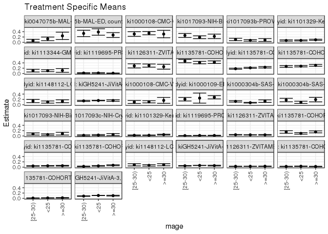

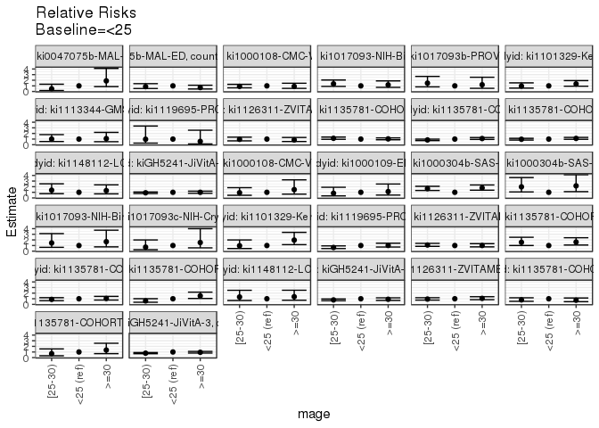

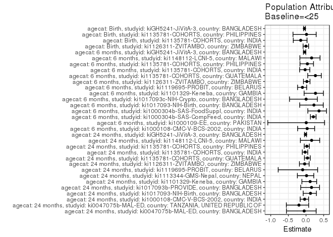

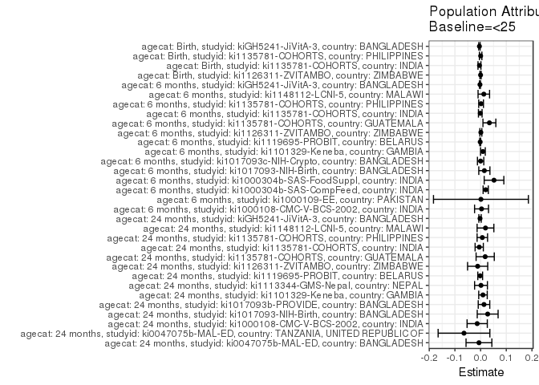

## Results Table

### Parameter: TSM

| agecat | studyid | country | intervention_level | baseline_level | estimate | ci_lower | ci_upper |
| --- | --- | --- | --- | --- | --- | --- | --- |
| Birth | ki1126311-ZVITAMBO | ZIMBABWE | <25 | NA | 0.0319043 | 0.0280588 | 0.0357498 |
| Birth | ki1126311-ZVITAMBO | ZIMBABWE | [25-30) | NA | 0.0302150 | 0.0244962 | 0.0359338 |
| Birth | ki1126311-ZVITAMBO | ZIMBABWE | >=30 | NA | 0.0339931 | 0.0266254 | 0.0413608 |
| Birth | ki1135781-COHORTS | INDIA | <25 | NA | 0.0336683 | 0.0257426 | 0.0415941 |
| Birth | ki1135781-COHORTS | INDIA | [25-30) | NA | 0.0269576 | 0.0189147 | 0.0350006 |
| Birth | ki1135781-COHORTS | INDIA | >=30 | NA | 0.0248500 | 0.0159179 | 0.0337822 |
| Birth | ki1135781-COHORTS | PHILIPPINES | <25 | NA | 0.0148810 | 0.0084069 | 0.0213551 |
| Birth | ki1135781-COHORTS | PHILIPPINES | [25-30) | NA | 0.0105263 | 0.0036844 | 0.0173682 |
| Birth | ki1135781-COHORTS | PHILIPPINES | >=30 | NA | 0.0199765 | 0.0105742 | 0.0293788 |
| Birth | kiGH5241-JiVitA-3 | BANGLADESH | <25 | NA | 0.1086442 | 0.1030802 | 0.1142083 |
| Birth | kiGH5241-JiVitA-3 | BANGLADESH | [25-30) | NA | 0.0855789 | 0.0748848 | 0.0962730 |
| Birth | kiGH5241-JiVitA-3 | BANGLADESH | >=30 | NA | 0.1022605 | 0.0874121 | 0.1171089 |
| 6 months | ki1000108-CMC-V-BCS-2002 | INDIA | <25 | NA | 0.1100917 | 0.0684854 | 0.1516980 |
| 6 months | ki1000108-CMC-V-BCS-2002 | INDIA | [25-30) | NA | 0.1018519 | 0.0447324 | 0.1589713 |
| 6 months | ki1000108-CMC-V-BCS-2002 | INDIA | >=30 | NA | 0.1627907 | 0.0522977 | 0.2732837 |
| 6 months | ki1000109-EE | PAKISTAN | <25 | NA | 0.2500000 | 0.0599703 | 0.4400297 |
| 6 months | ki1000109-EE | PAKISTAN | [25-30) | NA | 0.2071429 | 0.1399220 | 0.2743637 |
| 6 months | ki1000109-EE | PAKISTAN | >=30 | NA | 0.2809524 | 0.2200799 | 0.3418249 |
| 6 months | ki1000304b-SAS-CompFeed | INDIA | <25 | NA | 0.0759036 | 0.0632352 | 0.0885720 |
| 6 months | ki1000304b-SAS-CompFeed | INDIA | [25-30) | NA | 0.1256983 | 0.0987535 | 0.1526431 |
| 6 months | ki1000304b-SAS-CompFeed | INDIA | >=30 | NA | 0.1351351 | 0.0869951 | 0.1832751 |
| 6 months | ki1000304b-SAS-FoodSuppl | INDIA | <25 | NA | 0.0898204 | 0.0463980 | 0.1332427 |
| 6 months | ki1000304b-SAS-FoodSuppl | INDIA | [25-30) | NA | 0.1769231 | 0.1112389 | 0.2426073 |
| 6 months | ki1000304b-SAS-FoodSuppl | INDIA | >=30 | NA | 0.1927711 | 0.1077943 | 0.2777479 |
| 6 months | ki1017093-NIH-Birth | BANGLADESH | <25 | NA | 0.0507813 | 0.0238616 | 0.0777009 |
| 6 months | ki1017093-NIH-Birth | BANGLADESH | [25-30) | NA | 0.0740741 | 0.0337079 | 0.1144403 |
| 6 months | ki1017093-NIH-Birth | BANGLADESH | >=30 | NA | 0.0854701 | 0.0347631 | 0.1361770 |
| 6 months | ki1017093c-NIH-Crypto | BANGLADESH | <25 | NA | 0.0320856 | 0.0142129 | 0.0499582 |
| 6 months | ki1017093c-NIH-Crypto | BANGLADESH | [25-30) | NA | 0.0228311 | 0.0030350 | 0.0426271 |
| 6 months | ki1017093c-NIH-Crypto | BANGLADESH | >=30 | NA | 0.0491803 | 0.0107816 | 0.0875791 |

[output cut: 66 more lines]

### Parameter: E(Y)

| agecat | studyid | country | intervention_level | baseline_level | estimate | ci_lower | ci_upper |
| --- | --- | --- | --- | --- | --- | --- | --- |
| Birth | ki1126311-ZVITAMBO | ZIMBABWE | NA | NA | 0.0318347 | 0.0289044 | 0.0347649 |
| Birth | ki1135781-COHORTS | INDIA | NA | NA | 0.0292683 | 0.0244566 | 0.0340800 |
| Birth | ki1135781-COHORTS | PHILIPPINES | NA | NA | 0.0150820 | 0.0107558 | 0.0194081 |
| Birth | kiGH5241-JiVitA-3 | BANGLADESH | NA | NA | 0.1040657 | 0.0994001 | 0.1087313 |
| 6 months | ki1000108-CMC-V-BCS-2002 | INDIA | NA | NA | 0.1138211 | 0.0813725 | 0.1462698 |
| 6 months | ki1000109-EE | PAKISTAN | NA | NA | 0.2513514 | 0.2070910 | 0.2956117 |
| 6 months | ki1000304b-SAS-CompFeed | INDIA | NA | NA | 0.0958084 | 0.0774939 | 0.1141229 |
| 6 months | ki1000304b-SAS-FoodSuppl | INDIA | NA | NA | 0.1421053 | 0.1069532 | 0.1772573 |
| 6 months | ki1017093-NIH-Birth | BANGLADESH | NA | NA | 0.0654206 | 0.0444484 | 0.0863927 |
| 6 months | ki1017093c-NIH-Crypto | BANGLADESH | NA | NA | 0.0321678 | 0.0192256 | 0.0451101 |
| 6 months | ki1101329-Keneba | GAMBIA | NA | NA | 0.0336538 | 0.0259020 | 0.0414057 |
| 6 months | ki1119695-PROBIT | BELARUS | NA | NA | 0.0154178 | 0.0100323 | 0.0208033 |
| 6 months | ki1126311-ZVITAMBO | ZIMBABWE | NA | NA | 0.0416667 | 0.0373623 | 0.0459711 |
| 6 months | ki1135781-COHORTS | GUATEMALA | NA | NA | 0.1290323 | 0.1078261 | 0.1502385 |
| 6 months | ki1135781-COHORTS | INDIA | NA | NA | 0.0487357 | 0.0427089 | 0.0547626 |
| 6 months | ki1135781-COHORTS | PHILIPPINES | NA | NA | 0.0487445 | 0.0406327 | 0.0568562 |
| 6 months | ki1148112-LCNI-5 | MALAWI | NA | NA | 0.0792227 | 0.0587412 | 0.0997042 |
| 6 months | kiGH5241-JiVitA-3 | BANGLADESH | NA | NA | 0.0606882 | 0.0568343 | 0.0645421 |
| 24 months | ki0047075b-MAL-ED | BANGLADESH | NA | NA | 0.1226415 | 0.0783812 | 0.1669018 |
| 24 months | ki0047075b-MAL-ED | TANZANIA, UNITED REPUBLIC OF | NA | NA | 0.3224299 | 0.2596598 | 0.3852000 |
| 24 months | ki1000108-CMC-V-BCS-2002 | INDIA | NA | NA | 0.3306452 | 0.2827744 | 0.3785159 |
| 24 months | ki1017093-NIH-Birth | BANGLADESH | NA | NA | 0.2177986 | 0.1786036 | 0.2569935 |
| 24 months | ki1017093b-PROVIDE | BANGLADESH | NA | NA | 0.0849220 | 0.0621566 | 0.1076874 |
| 24 months | ki1101329-Keneba | GAMBIA | NA | NA | 0.0799300 | 0.0670879 | 0.0927720 |
| 24 months | ki1113344-GMS-Nepal | NEPAL | NA | NA | 0.1082164 | 0.0809323 | 0.1355005 |
| 24 months | ki1119695-PROBIT | BELARUS | NA | NA | 0.0161090 | 0.0034156 | 0.0288025 |
| 24 months | ki1126311-ZVITAMBO | ZIMBABWE | NA | NA | 0.2872807 | 0.2457035 | 0.3288579 |
| 24 months | ki1135781-COHORTS | GUATEMALA | NA | NA | 0.4292409 | 0.3995279 | 0.4589539 |
| 24 months | ki1135781-COHORTS | INDIA | NA | NA | 0.2081191 | 0.1950277 | 0.2212105 |
| 24 months | ki1135781-COHORTS | PHILIPPINES | NA | NA | 0.2817996 | 0.2639639 | 0.2996353 |
| 24 months | ki1148112-LCNI-5 | MALAWI | NA | NA | 0.1200000 | 0.0907456 | 0.1492544 |
| 24 months | kiGH5241-JiVitA-3 | BANGLADESH | NA | NA | 0.1557853 | 0.1470213 | 0.1645493 |

### Parameter: RR

| agecat | studyid | country | intervention_level | baseline_level | estimate | ci_lower | ci_upper |
| --- | --- | --- | --- | --- | --- | --- | --- |
| Birth | ki1126311-ZVITAMBO | ZIMBABWE | <25 | <25 | 1.0000000 | 1.0000000 | 1.0000000 |
| Birth | ki1126311-ZVITAMBO | ZIMBABWE | [25-30) | <25 | 0.9470511 | 0.7566958 | 1.1852925 |
| Birth | ki1126311-ZVITAMBO | ZIMBABWE | >=30 | <25 | 1.0654717 | 0.8314506 | 1.3653607 |
| Birth | ki1135781-COHORTS | INDIA | <25 | <25 | 1.0000000 | 1.0000000 | 1.0000000 |
| Birth | ki1135781-COHORTS | INDIA | [25-30) | <25 | 0.8006821 | 0.5475317 | 1.1708761 |
| Birth | ki1135781-COHORTS | INDIA | >=30 | <25 | 0.7380834 | 0.4802884 | 1.1342499 |
| Birth | ki1135781-COHORTS | PHILIPPINES | <25 | <25 | 1.0000000 | 1.0000000 | 1.0000000 |
| Birth | ki1135781-COHORTS | PHILIPPINES | [25-30) | <25 | 0.7073684 | 0.3235671 | 1.5464184 |
| Birth | ki1135781-COHORTS | PHILIPPINES | >=30 | <25 | 1.3424207 | 0.7071835 | 2.5482683 |
| Birth | kiGH5241-JiVitA-3 | BANGLADESH | <25 | <25 | 1.0000000 | 1.0000000 | 1.0000000 |
| Birth | kiGH5241-JiVitA-3 | BANGLADESH | [25-30) | <25 | 0.7876988 | 0.6887824 | 0.9008208 |
| Birth | kiGH5241-JiVitA-3 | BANGLADESH | >=30 | <25 | 0.9412420 | 0.8062159 | 1.0988824 |
| 6 months | ki1000108-CMC-V-BCS-2002 | INDIA | <25 | <25 | 1.0000000 | 1.0000000 | 1.0000000 |
| 6 months | ki1000108-CMC-V-BCS-2002 | INDIA | [25-30) | <25 | 0.9251543 | 0.4704531 | 1.8193321 |
| 6 months | ki1000108-CMC-V-BCS-2002 | INDIA | >=30 | <25 | 1.4786822 | 0.6799654 | 3.2156060 |
| 6 months | ki1000109-EE | PAKISTAN | <25 | <25 | 1.0000000 | 1.0000000 | 1.0000000 |
| 6 months | ki1000109-EE | PAKISTAN | [25-30) | <25 | 0.8285714 | 0.3625674 | 1.8935255 |
| 6 months | ki1000109-EE | PAKISTAN | >=30 | <25 | 1.1238095 | 0.5098337 | 2.4771759 |
| 6 months | ki1000304b-SAS-CompFeed | INDIA | <25 | <25 | 1.0000000 | 1.0000000 | 1.0000000 |
| 6 months | ki1000304b-SAS-CompFeed | INDIA | [25-30) | <25 | 1.6560255 | 1.3263229 | 2.0676870 |
| 6 months | ki1000304b-SAS-CompFeed | INDIA | >=30 | <25 | 1.7803518 | 1.3735037 | 2.3077131 |
| 6 months | ki1000304b-SAS-FoodSuppl | INDIA | <25 | <25 | 1.0000000 | 1.0000000 | 1.0000000 |
| 6 months | ki1000304b-SAS-FoodSuppl | INDIA | [25-30) | <25 | 1.9697436 | 1.0707512 | 3.6235212 |
| 6 months | ki1000304b-SAS-FoodSuppl | INDIA | >=30 | <25 | 2.1461847 | 1.1156667 | 4.1285709 |
| 6 months | ki1017093-NIH-Birth | BANGLADESH | <25 | <25 | 1.0000000 | 1.0000000 | 1.0000000 |
| 6 months | ki1017093-NIH-Birth | BANGLADESH | [25-30) | <25 | 1.4586895 | 0.6820094 | 3.1198614 |
| 6 months | ki1017093-NIH-Birth | BANGLADESH | >=30 | <25 | 1.6831032 | 0.7595982 | 3.7293881 |
| 6 months | ki1017093c-NIH-Crypto | BANGLADESH | <25 | <25 | 1.0000000 | 1.0000000 | 1.0000000 |
| 6 months | ki1017093c-NIH-Crypto | BANGLADESH | [25-30) | <25 | 0.7115677 | 0.2538884 | 1.9942961 |
| 6 months | ki1017093c-NIH-Crypto | BANGLADESH | >=30 | <25 | 1.5327869 | 0.5874156 | 3.9996142 |

[output cut: 66 more lines]

### Parameter: PAR

| agecat | studyid | country | intervention_level | baseline_level | estimate | ci_lower | ci_upper |
| --- | --- | --- | --- | --- | --- | --- | --- |
| Birth | ki1126311-ZVITAMBO | ZIMBABWE | <25 | NA | -0.0000696 | -0.0025526 | 0.0024133 |
| Birth | ki1135781-COHORTS | INDIA | <25 | NA | -0.0044000 | -0.0101398 | 0.0013397 |
| Birth | ki1135781-COHORTS | PHILIPPINES | <25 | NA | 0.0002010 | -0.0046662 | 0.0050683 |
| Birth | kiGH5241-JiVitA-3 | BANGLADESH | <25 | NA | -0.0045785 | -0.0072777 | -0.0018793 |
| 6 months | ki1000108-CMC-V-BCS-2002 | INDIA | <25 | NA | 0.0037294 | -0.0234478 | 0.0309065 |
| 6 months | ki1000109-EE | PAKISTAN | <25 | NA | 0.0013514 | -0.1834900 | 0.1861927 |
| 6 months | ki1000304b-SAS-CompFeed | INDIA | <25 | NA | 0.0199048 | 0.0098073 | 0.0300022 |
| 6 months | ki1000304b-SAS-FoodSuppl | INDIA | <25 | NA | 0.0522849 | 0.0140238 | 0.0905460 |
| 6 months | ki1017093-NIH-Birth | BANGLADESH | <25 | NA | 0.0146393 | -0.0070629 | 0.0363415 |
| 6 months | ki1017093c-NIH-Crypto | BANGLADESH | <25 | NA | 0.0000823 | -0.0122773 | 0.0124418 |
| 6 months | ki1101329-Keneba | GAMBIA | <25 | NA | 0.0090233 | -0.0001973 | 0.0182439 |
| 6 months | ki1119695-PROBIT | BELARUS | <25 | NA | -0.0015790 | -0.0035397 | 0.0003816 |
| 6 months | ki1126311-ZVITAMBO | ZIMBABWE | <25 | NA | 0.0010180 | -0.0028203 | 0.0048564 |
| 6 months | ki1135781-COHORTS | GUATEMALA | <25 | NA | 0.0342954 | 0.0091712 | 0.0594196 |
| 6 months | ki1135781-COHORTS | INDIA | <25 | NA | -0.0012883 | -0.0083370 | 0.0057603 |
| 6 months | ki1135781-COHORTS | PHILIPPINES | <25 | NA | 0.0018961 | -0.0073360 | 0.0111282 |
| 6 months | ki1148112-LCNI-5 | MALAWI | <25 | NA | 0.0125561 | -0.0098446 | 0.0349567 |
| 6 months | kiGH5241-JiVitA-3 | BANGLADESH | <25 | NA | -0.0024360 | -0.0044303 | -0.0004417 |
| 24 months | ki0047075b-MAL-ED | BANGLADESH | <25 | NA | -0.0063907 | -0.0566996 | 0.0439181 |
| 24 months | ki0047075b-MAL-ED | TANZANIA, UNITED REPUBLIC OF | <25 | NA | -0.0646669 | -0.1654207 | 0.0360870 |
| 24 months | ki1000108-CMC-V-BCS-2002 | INDIA | <25 | NA | -0.0132462 | -0.0526369 | 0.0261444 |
| 24 months | ki1017093-NIH-Birth | BANGLADESH | <25 | NA | 0.0275547 | -0.0130833 | 0.0681926 |
| 24 months | ki1017093b-PROVIDE | BANGLADESH | <25 | NA | 0.0132497 | -0.0092144 | 0.0357137 |
| 24 months | ki1101329-Keneba | GAMBIA | <25 | NA | 0.0093040 | -0.0072940 | 0.0259019 |
| 24 months | ki1113344-GMS-Nepal | NEPAL | <25 | NA | 0.0015988 | -0.0233585 | 0.0265561 |
| 24 months | ki1119695-PROBIT | BELARUS | <25 | NA | -0.0015407 | -0.0108550 | 0.0077735 |
| 24 months | ki1126311-ZVITAMBO | ZIMBABWE | <25 | NA | -0.0114745 | -0.0506898 | 0.0277408 |
| 24 months | ki1135781-COHORTS | GUATEMALA | <25 | NA | 0.0178772 | -0.0175306 | 0.0532851 |
| 24 months | ki1135781-COHORTS | INDIA | <25 | NA | -0.0053489 | -0.0213685 | 0.0106707 |
| 24 months | ki1135781-COHORTS | PHILIPPINES | <25 | NA | 0.0067523 | -0.0136332 | 0.0271379 |
| 24 months | ki1148112-LCNI-5 | MALAWI | <25 | NA | 0.0190385 | -0.0135879 | 0.0516648 |
| 24 months | kiGH5241-JiVitA-3 | BANGLADESH | <25 | NA | -0.0021863 | -0.0067713 | 0.0023988 |

### Parameter: PAF

| agecat | studyid | country | intervention_level | baseline_level | estimate | ci_lower | ci_upper |
| --- | --- | --- | --- | --- | --- | --- | --- |
| Birth | ki1126311-ZVITAMBO | ZIMBABWE | <25 | NA | -0.0021871 | -0.0832974 | 0.0728502 |
| Birth | ki1135781-COHORTS | INDIA | <25 | NA | -0.1503350 | -0.3624286 | 0.0287413 |
| Birth | ki1135781-COHORTS | PHILIPPINES | <25 | NA | 0.0133282 | -0.3683948 | 0.2885669 |
| Birth | kiGH5241-JiVitA-3 | BANGLADESH | <25 | NA | -0.0439963 | -0.0701820 | -0.0184513 |
| 6 months | ki1000108-CMC-V-BCS-2002 | INDIA | <25 | NA | 0.0327654 | -0.2378833 | 0.2442399 |
| 6 months | ki1000109-EE | PAKISTAN | <25 | NA | 0.0053763 | -1.0833442 | 0.5251499 |
| 6 months | ki1000304b-SAS-CompFeed | INDIA | <25 | NA | 0.2077560 | 0.1234546 | 0.2839498 |
| 6 months | ki1000304b-SAS-FoodSuppl | INDIA | <25 | NA | 0.3679308 | 0.0511262 | 0.5789625 |
| 6 months | ki1017093-NIH-Birth | BANGLADESH | <25 | NA | 0.2237723 | -0.1794585 | 0.4891474 |
| 6 months | ki1017093c-NIH-Crypto | BANGLADESH | <25 | NA | 0.0025575 | -0.4661566 | 0.3214289 |
| 6 months | ki1101329-Keneba | GAMBIA | <25 | NA | 0.2681210 | -0.0545125 | 0.4920432 |
| 6 months | ki1119695-PROBIT | BELARUS | <25 | NA | -0.1024161 | -0.2389502 | 0.0190717 |
| 6 months | ki1126311-ZVITAMBO | ZIMBABWE | <25 | NA | 0.0244324 | -0.0721425 | 0.1123083 |
| 6 months | ki1135781-COHORTS | GUATEMALA | <25 | NA | 0.2657895 | 0.0478511 | 0.4338437 |
| 6 months | ki1135781-COHORTS | INDIA | <25 | NA | -0.0264349 | -0.1817119 | 0.1084387 |
| 6 months | ki1135781-COHORTS | PHILIPPINES | <25 | NA | 0.0388984 | -0.1703287 | 0.2107206 |
| 6 months | ki1148112-LCNI-5 | MALAWI | <25 | NA | 0.1584906 | -0.1740057 | 0.3968188 |
| 6 months | kiGH5241-JiVitA-3 | BANGLADESH | <25 | NA | -0.0401394 | -0.0735390 | -0.0077789 |
| 24 months | ki0047075b-MAL-ED | BANGLADESH | <25 | NA | -0.0521092 | -0.5533306 | 0.2873805 |
| 24 months | ki0047075b-MAL-ED | TANZANIA, UNITED REPUBLIC OF | <25 | NA | -0.2005610 | -0.5579320 | 0.0748334 |
| 24 months | ki1000108-CMC-V-BCS-2002 | INDIA | <25 | NA | -0.0400618 | -0.1662899 | 0.0725046 |
| 24 months | ki1017093-NIH-Birth | BANGLADESH | <25 | NA | 0.1265146 | -0.0806121 | 0.2939401 |
| 24 months | ki1017093b-PROVIDE | BANGLADESH | <25 | NA | 0.1560215 | -0.1508232 | 0.3810519 |
| 24 months | ki1101329-Keneba | GAMBIA | <25 | NA | 0.1164017 | -0.1167818 | 0.3008965 |
| 24 months | ki1113344-GMS-Nepal | NEPAL | <25 | NA | 0.0147740 | -0.2450488 | 0.2203757 |
| 24 months | ki1119695-PROBIT | BELARUS | <25 | NA | -0.0956447 | -0.7889173 | 0.3289587 |
| 24 months | ki1126311-ZVITAMBO | ZIMBABWE | <25 | NA | -0.0399417 | -0.1857885 | 0.0879666 |
| 24 months | ki1135781-COHORTS | GUATEMALA | <25 | NA | 0.0416485 | -0.0445194 | 0.1207079 |
| 24 months | ki1135781-COHORTS | INDIA | <25 | NA | -0.0257013 | -0.1056280 | 0.0484474 |
| 24 months | ki1135781-COHORTS | PHILIPPINES | <25 | NA | 0.0239615 | -0.0511235 | 0.0936829 |
| 24 months | ki1148112-LCNI-5 | MALAWI | <25 | NA | 0.1586538 | -0.1593677 | 0.3894402 |
| 24 months | kiGH5241-JiVitA-3 | BANGLADESH | <25 | NA | -0.0140338 | -0.0438849 | 0.0149637 |